# Homework #1 by Yue Peng

```r
# Homework 1 for PHP2550
MC_Big <- read.csv("mcalindon_Big.csv")
dim(MC_Big)
```

1. 15428

2. 43

```r
# Extract the first observation for each individual
num <- rle(MC_Big$ID)
index <- c(cumsum(num$lengths) + 1)
index <- c(1, index)
Big <- MC_Big[index, ]
dim(Big)
```

1. 206

2. 43

#### a. Summarize the average pain score for each of the 7 days of the study.

```r
# a
ave_pain <- round(colMeans(data.frame(Big$pain.1, Big$pain.2, Big$pain.3, Big$pain.4,
     Big$pain.5, Big$pain.6, Big$pain.7), na.rm = TRUE),2)
df_a <- data.frame(Day=c(1:7), Pain=ave_pain)
colnames(df_a) <- c("Day", "Pain Score")
rownames(df_a) <- c(1:7)
```

```r
df_a
```

| Day | Pain Score |
| --- | --- |
| 1 | 8.94 |
| 2 | 7.99 |
| 3 | 7.49 |
| 4 | 7.32 |
| 5 | 6.79 |
| 6 | 7.02 |
| 7 | 6.50 |

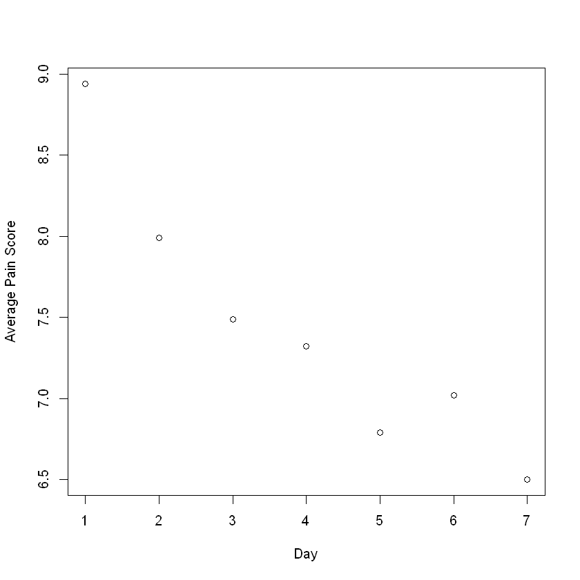

```r
plot(seq(7), ave_pain, xlab = "Day", ylab = "Average Pain Score")
```

#### b. Regress each pain score on age and use the summary function to create a summary table for each regression Then use the confint function to find the 95% confidence interval for the regression slopes and produce a table with the estimates, standard errors, p-values and confidence intervals of the 7 slopes and put these in a single table.

```r
model1 <- lm(Big$pain.1~Big$age)
print(summary(model1))
model2 <- lm(Big$pain.2~Big$age)
print(summary(model2))
model3 <- lm(Big$pain.3~Big$age)
print(summary(model3))
model4 <- lm(Big$pain.4~Big$age)
print(summary(model4))
model5 <- lm(Big$pain.5~Big$age)
print(summary(model5))
model6 <- lm(Big$pain.6~Big$age)
print(summary(model6))
model7 <- lm(Big$pain.7~Big$age)
print(summary(model7))
```

```
Call:
lm(formula = Big$pain.1 ~ Big$age)

Residuals:
    Min      1Q  Median      3Q     Max
-8.1071 -2.1278  0.1408  2.0168 11.3887

Coefficients:
            Estimate Std. Error t value Pr(>|t|)
(Intercept) 10.18148    1.54445   6.592 3.66e-10 ***
Big$age     -0.02066    0.02535  -0.815    0.416
---
Signif. codes:  0 '***' 0.001 '**' 0.01 '*' 0.05 '.' 0.1 ' ' 1

Residual standard error: 3.406 on 203 degrees of freedom
  (1 observation deleted due to missingness)
Multiple R-squared:  0.003261,	Adjusted R-squared:  -0.001649
F-statistic: 0.6642 on 1 and 203 DF,  p-value: 0.416


Call:
lm(formula = Big$pain.2 ~ Big$age)

Residuals:
    Min      1Q  Median      3Q     Max
-7.9802 -2.0812 -0.2833  2.2364 12.4529

Coefficients:
            Estimate Std. Error t value Pr(>|t|)
(Intercept)  9.74120    1.85034   5.265 4.59e-07 ***
Big$age     -0.02887    0.03012  -0.959    0.339
---
Signif. codes:  0 '***' 0.001 '**' 0.01 '*' 0.05 '.' 0.1 ' ' 1

Residual standard error: 3.603 on 156 degrees of freedom
  (48 observations deleted due to missingness)
Multiple R-squared:  0.005856,	Adjusted R-squared:  -0.000517
F-statistic: 0.9189 on 1 and 156 DF,  p-value: 0.3393


```

[output cut: 83 more lines]

```
Residuals:
    Min      1Q  Median      3Q     Max
-6.8762 -3.2389 -0.4889  2.9153 11.1791

Coefficients:
            Estimate Std. Error t value Pr(>|t|)
(Intercept)  9.86413    2.23231   4.419 1.96e-05 ***
Big$age     -0.05533    0.03630  -1.524     0.13
---
Signif. codes:  0 '***' 0.001 '**' 0.01 '*' 0.05 '.' 0.1 ' ' 1

Residual standard error: 4.015 on 142 degrees of freedom
  (62 observations deleted due to missingness)
Multiple R-squared:  0.0161,	Adjusted R-squared:  0.009169
F-statistic: 2.323 on 1 and 142 DF,  p-value: 0.1297
```

```r
res_confint <- c()
get_confint <- function(x){
    int_left <- confint(x, level=0.95)[2, 1]
    int_right <- confint(x, level=0.95)[2, 2]
    res_confint <- c(int_left, int_right)
    return(res_confint)
}
model = list(model1, model2, model3, model4, model5, model6, model7)
for (i in model){
   res_confint <- c(res_confint,get_confint(i))

}
```

```r
res_estimate <- c()
get_estimate <- function(x){
    res <- summary(x)[[4]][2,1]
}
for (i in model){
   res_estimate <- c(res_estimate,get_estimate(i))

}
```

```r
res_sd <- c()
get_sd <- function(x){
    res <- summary(x)[[4]][2,2]
}
for (i in model){
   res_sd <- c(res_sd,get_sd(i))

}
```

```r
res_pvalue <- c()
get_pvalue <- function(x){
    res <- summary(x)[[4]][2,4]
}
for (i in model){
   res_pvalue <- c(res_pvalue,get_pvalue(i))

}
```

```r
# reshape and organize
res_conf <- c()
i = 1
while (i <= 13){
    res_conf <- c(res_conf, paste0("(",round(res_confint[i], digits = 3),", ", round(res_confint[i+1], digits = 3), ")"))
    i = i + 2
}
rm(res_confint)

res_estimate <- round(res_estimate, digits = 3)


res_sd <- round(res_sd, digits = 3)

res_pvalue <- round(res_pvalue, digits = 3)
```

```r
# make it a table
df_b <- data.frame(estimate=res_estimate, standard_errors=res_sd, p_values=res_pvalue, CI=res_conf)
rownames(df_b) <- c("pain.1","pain.2","pain.3","pain.4","pain.5","pain.6","pain.7")
colnames(df_b) <- c("estimate", "standard errors", "p-values", "95% confidence intervals")
```

```r
df_b
```

|  | estimate | standard errors | p-values | 95% confidence intervals |
| --- | --- | --- | --- | --- |
| pain.1 | -0.021 | 0.025 | 0.416 | (-0.071, 0.029) |
| pain.2 | -0.029 | 0.030 | 0.339 | (-0.088, 0.031) |
| pain.3 | -0.035 | 0.034 | 0.308 | (-0.101, 0.032) |
| pain.4 | -0.028 | 0.032 | 0.379 | (-0.09, 0.034) |
| pain.5 | -0.058 | 0.032 | 0.075 | (-0.121, 0.006) |
| pain.6 | -0.029 | 0.032 | 0.374 | (-0.092, 0.035) |
| pain.7 | -0.055 | 0.036 | 0.130 | (-0.127, 0.016) |

#### c. For each individual fit a regression of pain on time. Summarize the slopes and intercepts produced.

```r
sub_Big_time <- data.frame(Big$pain.1, Big$pain.2, Big$pain.3, Big$pain.4, Big$pain.5, Big$pain.6, Big$pain.7)
# get rid of >= 5 NA and keep at least three point
clean_na <- function(x){
    if (sum(is.na(x)) >= 5){
        return(1)
    }else{
        return(0)
    }
}
idx1 <- c()
for (i in 1:(dim(sub_Big_time)[1])){
    if (clean_na(sub_Big_time[i,])){
        idx1 <- c(idx1, i)
    }
}
```

```r
# Extract time
time <- cbind(Big$lastdt1, Big$lastdt2, Big$lastdt3, Big$lastdt4, Big$lastdt5, Big$lastdt6, Big$lastdt7)[-idx1,]
for (i in (1:dim(time)[1])){
    time[i,] <- time[i,] - rep(time[i,1],7)
}
```

```r
# make table
df_c1 <- c()
for (i in 1:(dim(sub_Big_time[-idx1,])[1])){
    df_c1<- c(df_c1, summary(lm(as.numeric(sub_Big_time[-idx1,][i,])~time[i,], na.action=na.omit))[[4]][,1])
}
```

```r
tmp <- df_c1
x1 <- tmp[1]
x2 <- tmp[2]
i = 3
while (i <= 386){
    x1 <- c(x1, tmp[i])
    x2 <- c(x2, tmp[i+1])
    i = i + 2
}
rm(tmp)
x1 <- round(x1, digits = 2)
x2 <- round(x2, digits = 2)
df_c <- data.frame(slopes=x2,intercepts=x1)
rownames(df_c) <- as.character(Big$ID[-idx1])
```

```r
summary(df_c$slopes)
```

```
    Min.  1st Qu.   Median     Mean  3rd Qu.     Max.
-0.14000 -0.06000 -0.03000 -0.02642  0.00000  0.14000
```

```r
summary(df_c$intercepts)
```

```
   Min. 1st Qu.  Median    Mean 3rd Qu.    Max.
  0.650   6.200   8.520   8.603  10.830  21.290
```

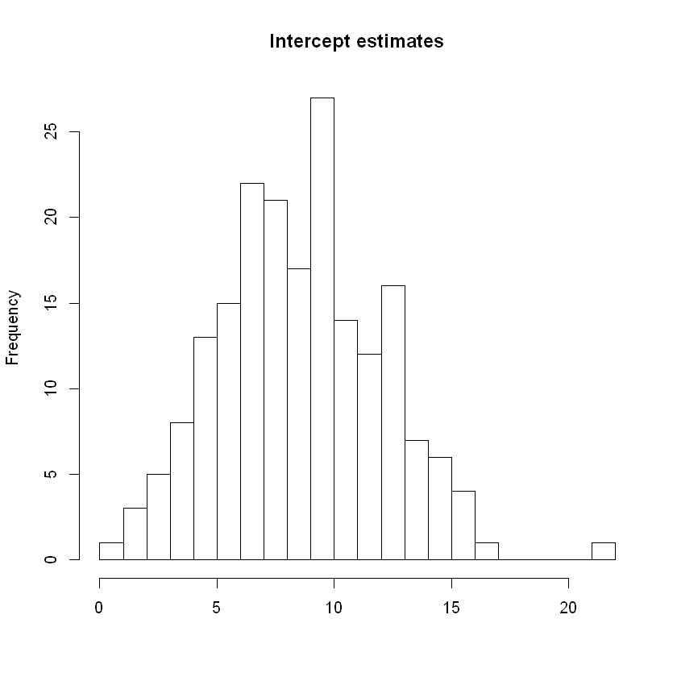

```r
hist(df_c$intercepts, breaks = 20, xlab = "", main = "Intercept estimates")
```

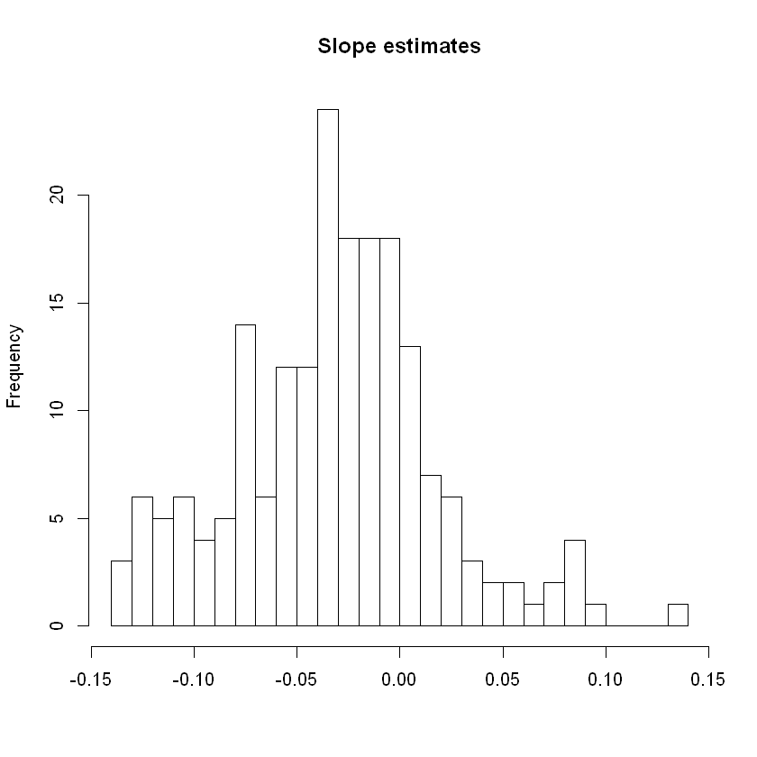

```r
hist(df_c$slopes, breaks = 20, xlab = "", main = "Slope estimates")
```

#### d. Are the slopes or intercepts related to any of the patient characteristics (age, race, income, treatment, sex, occupation, working status, use of NSAIDs,)?

```r
# Race
p_race1 <- cor.test(df_c$intercepts, Big$racecat[-idx1])[[3]]
p_race2 <- cor.test(df_c$slopes, Big$racecat[-idx1])[[3]]
# Age
p_age1 <- cor.test(df_c$intercepts, Big$agecat[-idx1])[[3]]
p_age2 <- cor.test(df_c$slopes, Big$agecat[-idx1])[[3]]
# income
p_income1 <- cor.test(df_c$intercepts, Big$inccat[-idx1])[[3]]
p_income2 <- cor.test(df_c$slopes, Big$inccat[-idx1])[[3]]
# treatment
p_trt1 <- cor.test(df_c$intercepts, Big$treat[-idx1])[[3]]
p_trt2 <- cor.test(df_c$slopes, Big$treat[-idx1])[[3]]
# sex
p_sex1 <- cor.test(df_c$intercepts, Big$sex[-idx1])[[3]]
p_sex2 <- cor.test(df_c$slopes, Big$sex[-idx1])[[3]]
# retire
p_retire1 <- cor.test(df_c$intercepts, Big$retire[-idx1])[[3]]
p_retire2 <- cor.test(df_c$slopes, Big$retire[-idx1])[[3]]
# NSAIDs
p_nsaids1 <- cor.test(df_c$intercepts, Big$nsaid[-idx1])[[3]]
p_nsaids2 <- cor.test(df_c$slopes, Big$nsaid[-idx1])[[3]]
```

```r
df_d <- data.frame(intercepts=round(c(p_age1, p_race1, p_income1, p_trt1, p_sex1, p_retire1, p_nsaids1), digits = 3),
                      slopes=round(c(p_age2, p_race2, p_income2, p_trt2, p_sex2, p_retire2, p_nsaids2), digits = 3),
                   related1=c(NA),related2=c(NA))
rownames(df_d) <- c("Age", "Race", "Income", "Treatment", "Sex", "Working Status", "Use of NSAIDs")
```

```r
related <- function(x){
    if (x > 0.05){
        return("Not related")
    }else{
        return("Related")
    }
}
related1 <- c()
for (i in 1:7){
    related1 <- c(related1, related(df_d$intercepts[i]))
}
related2 <- c()
for (i in 1:7){
    related2 <- c(related2, related(df_d$slopes[i]))
}
df_d$related1 <- related1
df_d$related2 <- related2
colnames(df_d) <- c("P-values of intercepts", "P-values of slopes", "Related to intercept", "Related to slope")
```

```r
df_d
```

|  | P-values of intercepts | P-values of slopes | Related to intercept | Related to slope |
| --- | --- | --- | --- | --- |
| Age | 0.805 | 0.772 | Not related | Not related |
| Race | 0.762 | 0.523 | Not related | Not related |
| Income | 0.290 | 0.925 | Not related | Not related |
| Treatment | 0.484 | 0.383 | Not related | Not related |
| Sex | 0.210 | 0.824 | Not related | Not related |
| Working Status | 0.232 | 0.472 | Not related | Not related |
| Use of NSAIDs | 0.373 | 0.029 | Not related | Related |

#### e. For each individual, compute the correlation between pain scores and average temperature on the dates the pain scores were taken and constuct a graph to display these correlations. Discuss whether pain is correlated with temperature.

```r
# Extract WeatherDate and corresponding avetemp
WT <- data.frame(ID=MC_Big$ID, WeatherDate=MC_Big$WeatherDate, avgtemp=MC_Big$avgtemp)
find_temp <- function(x, y){
    if (is.na(y)){
        return(NA)
    }else{
    return(WT$avgtemp[which(WT$ID==x & WT$WeatherDate==y)])
        }
}
```

```r
# add avetemp for each day into used data
Big$temp1 <- mapply(find_temp, Big$ID, Big$lastdt1)
Big$temp2 <- mapply(find_temp, Big$ID, Big$lastdt2)
Big$temp3 <- mapply(find_temp, Big$ID, Big$lastdt3)
Big$temp4 <- mapply(find_temp, Big$ID, Big$lastdt4)
Big$temp5 <- mapply(find_temp, Big$ID, Big$lastdt5)
Big$temp6 <- mapply(find_temp, Big$ID, Big$lastdt6)
Big$temp7 <- mapply(find_temp, Big$ID, Big$lastdt7)
```

```r
cor_e <- c()
for (i in c(1:206)[-idx1]){
    cor_e <- c(cor_e, cor(c(Big$pain.1[i], Big$pain.2[i], Big$pain.3[i], Big$pain.4[i], Big$pain.5[i], Big$pain.6[i],
              Big$pain.7[i]),
            c(Big$temp1[i], Big$temp2[i], Big$temp3[i], Big$temp4[i], Big$temp5[i], Big$temp6[i],
              Big$temp7[i]), use="na.or.complete"))
}
```

```r
cor_e <- round(cor_e, digits = 3)
```

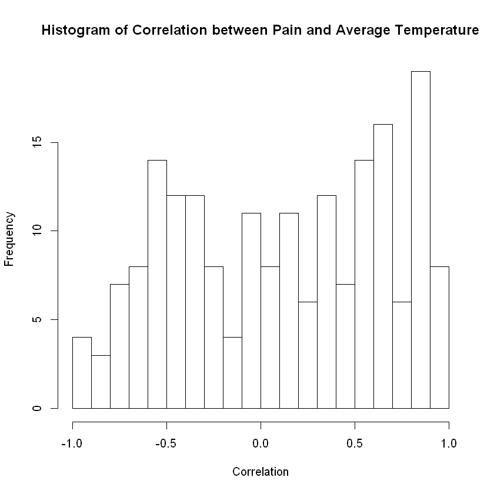

```r
hist(cor_e, breaks=20, xlab = "Correlation", main = "Histogram of Correlation between Pain and Average Temperature")
```

#### In the paper by Wang et al. (paper #5 in your syllabus), reproduce Table 2 using just the outcome data without trying to fit the mixed model.

```r
Wang <- read.csv("Wang.csv")
dim(Wang)
```

1. 40

2. 84

```r
Wpain_tc1 <- c(lm(Wang$womac.pain.2[Wang$group==1]-Wang$womac.pain.1[Wang$group==1]~1)[[5]][1],
             lm(Wang$womac.pain.3[Wang$group==1]-Wang$womac.pain.1[Wang$group==1]~1)[[5]][1],
             lm(Wang$womac.pain.4[Wang$group==1]-Wang$womac.pain.1[Wang$group==1]~1)[[5]][1])
Wpain_tc2 <- c(confint(lm(Wang$womac.pain.2[Wang$group==1]-Wang$womac.pain.1[Wang$group==1]~1)),
              confint(lm(Wang$womac.pain.3[Wang$group==1]-Wang$womac.pain.1[Wang$group==1]~1)),
              confint(lm(Wang$womac.pain.4[Wang$group==1]-Wang$womac.pain.1[Wang$group==1]~1)))
```

```r
find_value <- function(var, group, date){
    if (group == 3){
        return(
        paste0(round(lm((Wang[,paste0(var,date)][Wang$group==1]-Wang[,paste0(var,date)][Wang$group==0])-
                        (Wang[,paste0(var,"1")][Wang$group==1]-Wang[,paste0(var,"1")][Wang$group==0])~1)[[5]][1], digits = 2),
              " (", round(confint(lm((Wang[,paste0(var,date)][Wang$group==1]-Wang[,paste0(var,date)][Wang$group==0])-
                        (Wang[,paste0(var,"1")][Wang$group==1]-Wang[,paste0(var,"1")][Wang$group==0])~1))[1], digits = 2),
              " to ",
               round(confint(lm((Wang[,paste0(var,date)][Wang$group==1]-Wang[,paste0(var,date)][Wang$group==0])-
                        (Wang[,paste0(var,"1")][Wang$group==1]-Wang[,paste0(var,"1")][Wang$group==0])~1))[2], digits = 2),
              ")")
        )
    }else{
    return(
        paste0(round(lm(Wang[,paste0(var,date)][Wang$group==group]-Wang[,paste0(var,"1")][Wang$group==group]~1)[[5]][1], digits = 2),
              " (", round(confint(lm(Wang[,paste0(var,date)][Wang$group==group]-Wang[,paste0(var,"1")][Wang$group==group]~1))[1], digits = 2),
              " to ",
               round(confint(lm(Wang[,paste0(var,date)][Wang$group==group]-Wang[,paste0(var,"1")][Wang$group==group]~1))[2], digits = 2),
              ")")
              )
        }
}
```

```r
find_p <- function(var, date){
    return(signif(summary(lm((Wang[,paste0(var,date)][Wang$group==1]-Wang[,paste0(var,date)][Wang$group==0])-
                        (Wang[,paste0(var,"1")][Wang$group==1]-Wang[,paste0(var,"1")][Wang$group==0])~1))$coef[4],digits=2))
}
```

```r
var <- c("womac.pain.", "womac.phys.func.", "womac.stiff.", "physician.vas.", "pt.global.vas.", "walkyard.", "balance.",
        "chairstand.", "mcs.", "pcs.", "cesd.", "self.efficacy.")
date <- c("2", "3", "4")
group <- c(1, 0, 3)
```

```r
values <- function(x, y){
    tmp <- c()
for (i in group){
    tmp <- c(tmp, mapply(find_value, var[x], i, date[y]))
 }
    tmp <- c(tmp, find_p(var[x], date[y]))
    return(tmp)
}
```

```r
df_2 <- rbind(values(1,1), values(1,2), values(1,3))
for (i in 2:12){
 df_2 <- rbind(df_2, rbind(values(i,1), values(i,2), values(i,3)))
    }
```

```r
dim(df_2)
```

1. 36

2. 4

```r
table2 <- data.frame(Variable=c("WOMAC-Pain, 0-500 mm Week 12", "Week 24", "Week 48", "WOMAC-Physical Function, 0-1700 mm,Week 12",
                                "Week 24", "Week 48",
                                "WOMAC-Stiffness, 0-200 mm Week 12", "Week 24", "Week 48",
                               "Physician, 0-10 cm VAS Week 12", "Week 24", "Week 48",
                                "Patient Global, 0-10 cm VAS Week 12", "Week 24", "Week 48",
                                "6 Minute Walk Test(yards) Week 12", "Week 24", "Week 48",
                               "Balance Score, 0-5 Week 12", "Week 24", "Week 48",
                                "Chair Stand Time(seconds) Week 12", "Week 24", "Week 48",
                                "SF-36 Mental Component Summary, 0-100 Week 12", "Week 24", "Week 48",
                               "SF-36 Physical Component Summary, 0-100 Week 12", "Week 24", "Week 48",
                                "CES-D, 0-60 Week 12", "Week 24", "Week 48",
                                "Self-Efficacy Score, 1-5 Week 12", "Week 24", "Week 48"),
                    Taichi=df_2[,1], Control=df_2[,2], TvsC=df_2[,3], pvalue=df_2[,4])
colnames(table2) <- c("Varibale", "Tai chi", "Control", "Tai chi vs Control", "P-value")
```

```r
table2
```

| Varibale | Tai chi | Control | Tai chi vs Control | P-value |
| --- | --- | --- | --- | --- |
| WOMAC-Pain, 0-500 mm Week 12 | -157.25 (-198.51 to -115.99) | -38.45 (-87.18 to 10.28) | -118.8 (-180.77 to -56.83) | 0.00074 |
| Week 24 | -131.55 (-179.63 to -83.47) | -64.6 (-116.08 to -13.12) | -66.95 (-129.89 to -4.01) | 0.038 |
| Week 48 | -115.35 (-172.19 to -58.51) | -69.2 (-126.53 to -11.87) | -46.15 (-126.44 to 34.14) | 0.24 |
| WOMAC-Physical Function, 0-1700 mm,Week 12 | -506.75 (-635.52 to -377.98) | -182.15 (-321.8 to -42.5) | -324.6 (-490.76 to -158.44) | 0.00063 |
| Week 24 | -440.5 (-582.58 to -298.42) | -257.3 (-408.63 to -105.97) | -183.2 (-363.18 to -3.22) | 0.046 |
| Week 48 | -405.85 (-577.68 to -234.02) | -300.55 (-452.98 to -148.12) | -105.3 (-296.03 to 85.43) | 0.26 |
| WOMAC-Stiffness, 0-200 mm Week 12 | -73.05 (-90.49 to -55.61) | -50.15 (-75.84 to -24.46) | -22.9 (-48.18 to 2.38) | 0.073 |
| Week 24 | -65 (-87.16 to -42.84) | -50.2 (-72.99 to -27.41) | -14.8 (-43.12 to 13.52) | 0.29 |
| Week 48 | -64.15 (-86.18 to -42.12) | -60.5 (-88.89 to -32.11) | -3.65 (-40.03 to 32.73) | 0.84 |
| Physician, 0-10 cm VAS Week 12 | -3.15 (-3.88 to -2.41) | -1.44 (-2.1 to -0.78) | -1.71 (-2.73 to -0.68) | 0.0025 |
| Week 24 | -2.6 (-3.37 to -1.82) | -2.06 (-2.95 to -1.17) | -0.53 (-1.65 to 0.58) | 0.33 |
| Week 48 | -2.54 (-3.62 to -1.45) | -1.54 (-2.25 to -0.83) | -0.98 (-2.19 to 0.22) | 0.1 |
| Patient Global, 0-10 cm VAS Week 12 | -2.98 (-3.94 to -2.02) | -0.83 (-1.86 to 0.21) | -2.15 (-3.47 to -0.83) | 0.0029 |
| Week 24 | -2.36 (-3.63 to -1.09) | -1.71 (-2.98 to -0.44) | -0.65 (-2.23 to 0.93) | 0.4 |
| Week 48 | -1.65 (-3.4 to 0.09) | -1.7 (-3.15 to -0.24) | 0.04 (-2.17 to 2.25) | 0.97 |
| 6 Minute Walk Test(yards) Week 12 | 40.28 (9.3 to 71.27) | -1.42 (-42.17 to 39.33) | 41.12 (-18.33 to 100.57) | 0.16 |
| Week 24 | 44.28 (8.36 to 80.19) | 7.84 (-27.9 to 43.58) | 36 (-22.87 to 94.87) | 0.22 |
| Week 48 | 28.75 (-12.45 to 69.94) | 17.14 (-17.27 to 51.55) | 4.73 (-56.23 to 65.68) | 0.87 |
| Balance Score, 0-5 Week 12 | 0.15 (-0.08 to 0.38) | 0.25 (-0.05 to 0.55) | -0.1 (-0.53 to 0.33) | 0.63 |
| Week 24 | 0.15 (-0.16 to 0.46) | 0.07 (-0.37 to 0.52) | 0.07 (-0.52 to 0.67) | 0.8 |
| Week 48 | 0.35 (0.04 to 0.66) | 0.47 (0.07 to 0.88) | -0.16 (-0.72 to 0.4) | 0.56 |
| Chair Stand Time(seconds) Week 12 | -12.03 (-16.68 to -7.39) | -0.94 (-4.84 to 2.97) | -11.1 (-16.64 to -5.56) | 0.00053 |
| Week 24 | -9.88 (-14.08 to -5.67) | -4.81 (-9.28 to -0.33) | -5.07 (-10.9 to 0.77) | 0.085 |
| Week 48 | -9.23 (-14.62 to -3.83) | -3.8 (-8.01 to 0.41) | -4 (-9.49 to 1.48) | 0.14 |
| SF-36 Mental Component Summary, 0-100 Week 12 | 2.14 (-4.02 to 8.31) | 1.93 (-2.62 to 6.49) | 0.21 (-7.12 to 7.54) | 0.95 |
| Week 24 | 4.39 (-2.06 to 10.84) | 4.5 (0.87 to 8.13) | -0.11 (-7.57 to 7.35) | 0.98 |
| Week 48 | 5.8 (-0.46 to 12.07) | 1.04 (-5.07 to 7.14) | 4.77 (-5.03 to 14.57) | 0.32 |
| SF-36 Physical Component Summary, 0-100 Week 12 | 11.57 (7.61 to 15.53) | 4.14 (0.68 to 7.6) | 7.43 (1.75 to 13.11) | 0.013 |
| Week 24 | 10.8 (6.69 to 14.91) | 6.29 (1.98 to 10.59) | 4.51 (-2.35 to 11.37) | 0.18 |
| Week 48 | 10.41 (5.64 to 15.18) | 4.1 (0 to 8.2) | 6.32 (-0.45 to 13.08) | 0.065 |
| CES-D, 0-60 Week 12 | -7.4 (-11.38 to -3.42) | -0.7 (-3.88 to 2.48) | -6.7 (-12 to -1.4) | 0.016 |
| Week 24 | -6.4 (-11.39 to -1.41) | -1.1 (-5.04 to 2.84) | -5.3 (-11.52 to 0.92) | 0.091 |
| Week 48 | -7.25 (-11.77 to -2.73) | 1.65 (-2.39 to 5.69) | -8.9 (-14.92 to -2.88) | 0.0059 |
| Self-Efficacy Score, 1-5 Week 12 | 0.6 (-0.01 to 1.21) | -0.11 (-0.53 to 0.31) | 0.71 (-0.06 to 1.48) | 0.07 |
| Week 24 | 0.68 (0.13 to 1.23) | -0.17 (-0.69 to 0.35) | 0.85 (0.08 to 1.62) | 0.032 |
| Week 48 | 0.72 (0 to 1.44) | -0.24 (-0.65 to 0.17) | 0.96 (0.18 to 1.74) | 0.018 |